# HBoV-1 Persistence Modeling

### Shape of the infectivity curve

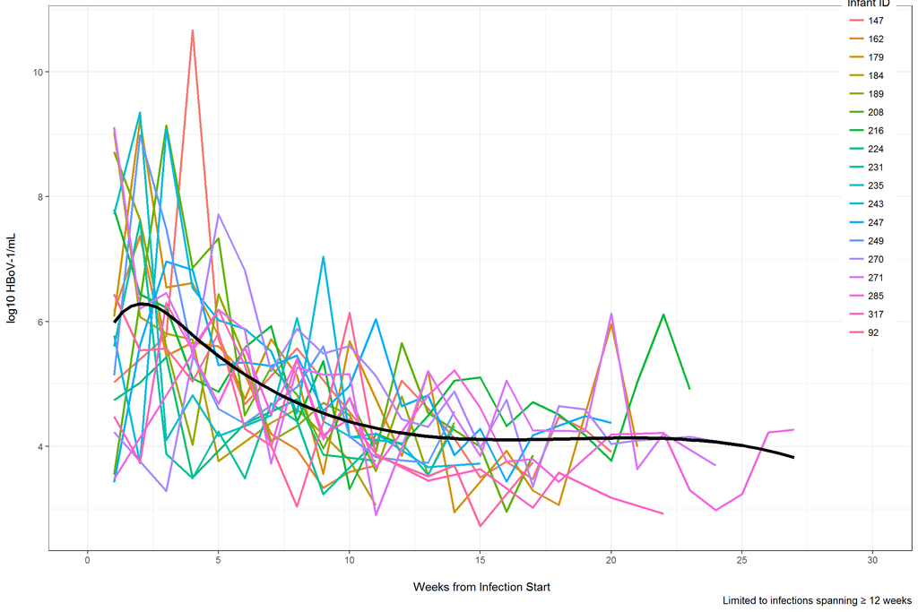

```r
p <- duration_def1 %>%
  filter(id %in% names(which(table(.$id) > 10))) %>%
  filter(!is.na(log_q_per_ml)) %>%
  ggplot(aes(x = time)) %>%
  add(geom_line(aes(y = log_q_per_ml, color = id), size = 1.05)) %>%
  add(geom_smooth(aes(y = log_q_per_ml),
                  method = "gam",
                  formula = y ~ splines::bs(x, knots = c(0, 1, 4)),
                  color = "black",
                  se = FALSE,
                  size = 1.5)) %>%
  add(theme_bw()) %>%
  add(scale_x_continuous(breaks = seq(0, 30, by = 5),
                         limits = c(0, 30))) %>%
  add(theme(legend.position = c(0.95, 0.7))) %>%
  add(labs(x = "\n Weeks from Infection Start",
           y = "log10 HBoV-1/mL\n",
           color = "Infant ID",
           caption = "Limited to infections spanning \u2265 12 weeks"))
p
```

#### GAM and GAMM modelling

The shape of the curve is non-linear, as with most biological curves. Generalized Additive Models (GAM) can estimate these curves with penalized spline terms. Further, Generalized Additive Mixed Models (GAMM) can take into account the random effect of different individual experiences, which is ultimately what we want to model.

```r
library(mgcv)

df_10 <- filter(duration_def1, id %in% names(which(table(duration_def1$id) > 10)))
gam_fit <- gam(log_q_per_ml ~ s(time, k = -1, bs = "cr"),
               family = gaussian(link = identity),
               data = df_10)
sp <- gam_fit$sp
summary(gam_fit)
```

```
##
## Family: gaussian
## Link function: identity
##
## Formula:
## log_q_per_ml ~ s(time, k = -1, bs = "cr")
##
## Parametric coefficients:
##             Estimate Std. Error t value Pr(>|t|)
## (Intercept)  4.85425    0.06383   76.05   <2e-16 ***
## ---
## Signif. codes:  0 '***' 0.001 '**' 0.01 '*' 0.05 '.' 0.1 ' ' 1
##
## Approximate significance of smooth terms:
##           edf Ref.df     F p-value
## s(time) 2.705  3.386 40.14  <2e-16 ***
## ---
## Signif. codes:  0 '***' 0.001 '**' 0.01 '*' 0.05 '.' 0.1 ' ' 1
##
## R-sq.(adj) =  0.326   Deviance explained = 33.3%
## GCV = 1.1723  Scale est. = 1.157     n = 284
```

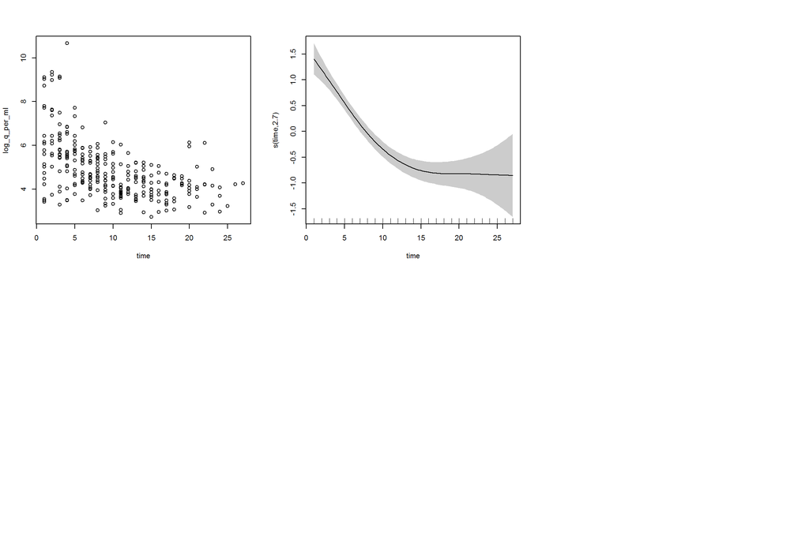

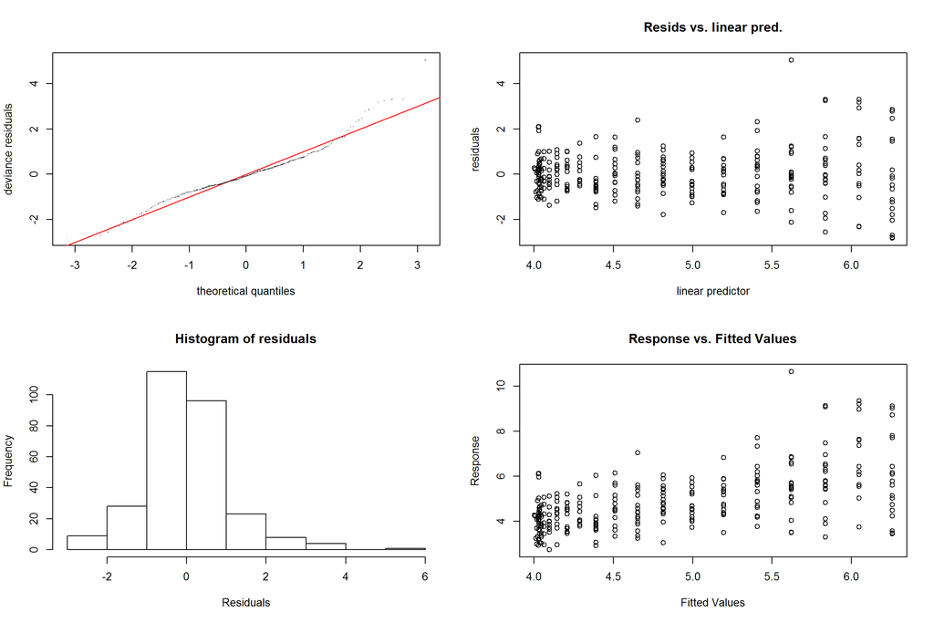

```
##
## Method: GCV   Optimizer: magic
## Smoothing parameter selection converged after 5 iterations.
## The RMS GCV score gradient at convergence was 1.79011e-05 .
## The Hessian was positive definite.
## Model rank =  10 / 10
##
## Basis dimension (k) checking results. Low p-value (k-index<1) may
## indicate that k is too low, especially if edf is close to k'.
##
##          k' edf k-index p-value
## s(time) 9.0 2.7    1.01    0.56
```

```r
par(mfrow = c(2, 3))
with(df_10, plot(time, log_q_per_ml))
plot(gam_fit, select = 1, shade = TRUE)
gam.check(gam_fit)
```

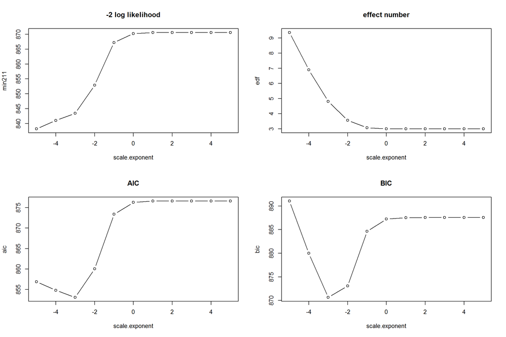

```r
# png("S:/MartinEpi/Analysis/Bocavirus Persistence Modeling/plots and figures/gam.png",
#     width = 12, height = 8, units = "in", res = 700)
# par(mfrow = c(2, 3))
# with(duration_def1, plot(time, log_q_per_ml))
# plot(gam_fit, select = 1, shade = TRUE)
# gam.check(gam_fit)
# dev.off()

# find best smooth by aic/bic
tuning.scale <- c(1e-5, 1e-4, 1e-3, 1e-2, 1e-1, 1e0, 1e1, 1e2, 1e3, 1e4, 1e5)
scale.exponent <- log10(tuning.scale)
n.tuning <- length(tuning.scale)
edf <- rep(NA, n.tuning)
min211 <- rep(NA, n.tuning)
aic <- rep(NA, n.tuning)
bic <- rep(NA, n.tuning)

for(i in 1:n.tuning) {
  gam_fit <- gam(log_q_per_ml ~ s(time),
               family = gaussian(link = identity),
               data = df_10,
               sp = tuning.scale[i] * sp)
  min211[i] <- -2 * logLik(gam_fit)
  edf[i] <- sum(gam_fit$edf) + 1
  aic[i] <- AIC(gam_fit)
  bic[i] <- BIC(gam_fit)
}

par(mfrow = c(2, 2))
plot(scale.exponent, min211, type = "b", main = "-2 log likelihood")
plot(scale.exponent, edf, type = "b", main = "effect number")
plot(scale.exponent, aic, type = "b", main = "AIC")
plot(scale.exponent, bic, type = "b", main = "BIC")
```

```r
# scaling corresponding to minimum bic
min.bic <- 1e100
opt.tuning.scale <- NULL
for (i in 1:n.tuning) {
  if (bic[i] < min.bic) {
    min.bic <- bic[i]
    opt.tuning.scale <- tuning.scale[i]
  }
}

opt.sp <- opt.tuning.scale * sp
opt.sp
```

```
##   s(time)
## 0.9388849
```

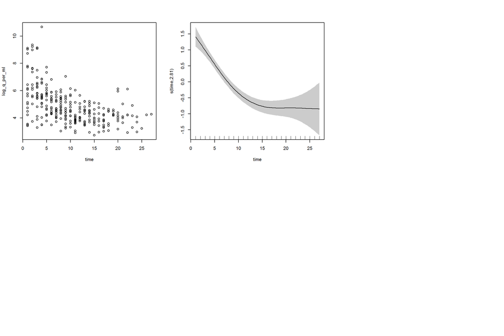

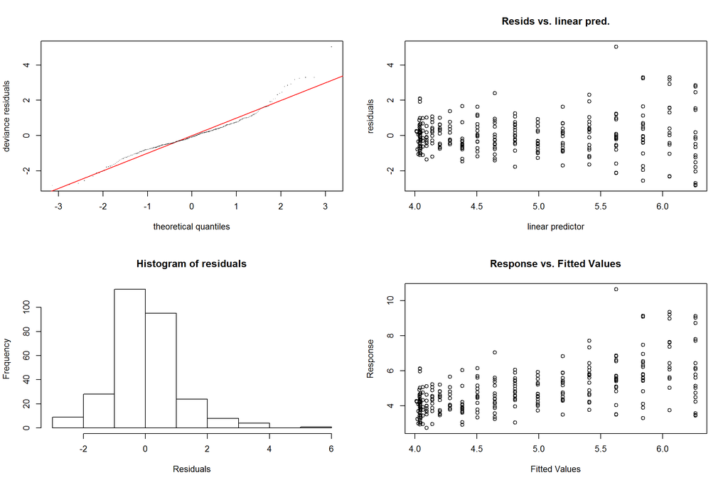

```
##
## Method: GCV   Optimizer: magic
## Model required no smoothing parameter selectionModel rank =  10 / 10
##
## Basis dimension (k) checking results. Low p-value (k-index<1) may
## indicate that k is too low, especially if edf is close to k'.
##
##           k'  edf k-index p-value
## s(time) 9.00 2.81    1.02    0.54
```

```r
gam_fit <- gam_fit <- gam(log_q_per_ml ~ s(time),
                          family = gaussian(link = identity),
                          data = df_10,
                          sp = opt.sp)

par(mfrow = c(2, 3))
with(df_10, plot(time, log_q_per_ml))
plot(gam_fit, select = 1, shade = TRUE)
gam.check(gam_fit)
```

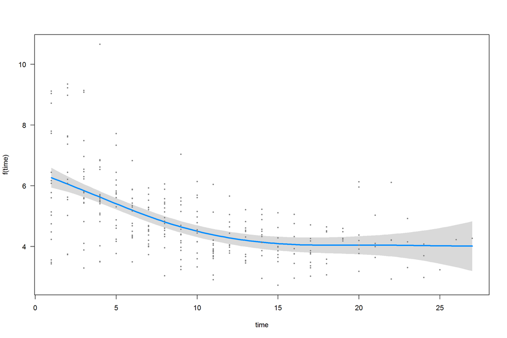

```r
par(mfrow = c(1, 1))

visreg(gam_fit)
```

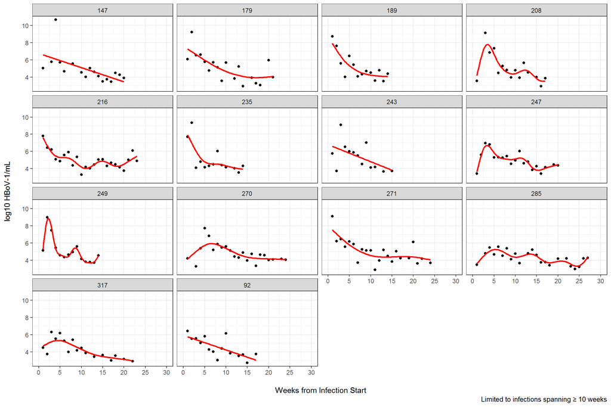

```r
# png("S:/MartinEpi/Analysis/Bocavirus Persistence Modeling/plots and figures/infection_curve.png",
#     width = 10, height = 8, units = "in", res = 500)
# p
# dev.off()

p <- duration_def1 %>%
  filter(id %in% names(which(table(.$id) > 12))) %>%
  filter(!is.na(log_q_per_ml)) %>%
  ggplot(aes(x = time)) %>%
  add(geom_point(aes(y = log_q_per_ml))) %>%
  add(geom_smooth(aes(y = log_q_per_ml),
                  method = "gam",
                  formula = y ~ s(x),
                  color = "red",
                  alpha = 0.1,
                  se = FALSE)) %>%
  add(facet_wrap(~id)) %>%
  add(theme_bw()) %>%
  add(scale_x_continuous(breaks = seq(0, 30, by = 5),
                         limits = c(0, 30))) %>%
  add(theme(legend.position = c(0.95, 0.6))) %>%
  add(labs(x = "\n Weeks from Infection Start",
           y = "log10 HBoV-1/mL\n",
           caption = "Limited to infections spanning \u2265 10 weeks"))
p
```

```r
# png("S:/MartinEpi/Analysis/Bocavirus Persistence Modeling/plots and figures/infection_curve_individual.png",
#     width = 12, height = 10, units = "in", res = 500)
# p
# dev.off()
```

GAMM

```r
library(itsadug)
df_red <- df_10 %>%
  mutate(id = factor(id),
         siblings = factor(siblings,
                           levels = c(0, 1),
                           labels = c("No", "Yes")),
         day_care = factor(day_care,
                           levels = c(0, 1),
                           labels = c("No", "Yes")),
         female = factor(female,
                         levels = c(0, 1),
                         labels = c("Male", "Female")),
         bf_duration = ifelse(is.na(bf_duration), 0, bf_duration)) %>%
  select(log_q_per_ml, siblings, day_care, female, bf_duration, time, id) %>%
  filter(!is.na(log_q_per_ml))
```

Simple GAM with spline for time by day_care attendance

```r
dc_gam_1 <- gam(log_q_per_ml ~ day_care + s(time, by = day_care),
                data = df_red)
summary(dc_gam_1)
```

```
##
## Family: gaussian
## Link function: identity
##
## Formula:
## log_q_per_ml ~ day_care + s(time, by = day_care)
##
## Parametric coefficients:
##             Estimate Std. Error t value Pr(>|t|)
## (Intercept)  4.79162    0.08914  53.757   <2e-16 ***
## day_careYes  0.12704    0.12659   1.004    0.316
## ---
## Signif. codes:  0 '***' 0.001 '**' 0.01 '*' 0.05 '.' 0.1 ' ' 1
##
## Approximate significance of smooth terms:
##                       edf Ref.df    F  p-value
## s(time):day_careNo  5.787  6.908  9.2 3.86e-10 ***
## s(time):day_careYes 2.659  3.315 26.1 5.70e-16 ***
## ---
## Signif. codes:  0 '***' 0.001 '**' 0.01 '*' 0.05 '.' 0.1 ' ' 1
##
## R-sq.(adj) =  0.345   Deviance explained = 36.7%
## GCV = 1.1674  Scale est. = 1.1245    n = 284
```

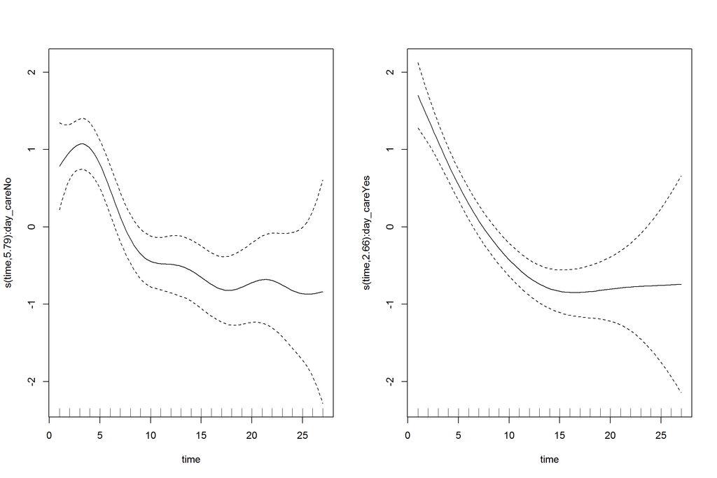

```r
par(mfrow = c(1, 2))
plot(dc_gam_1)
```

GAMM with random intercept for each subject, by day_care attendance

```r
dc_gam_2 <- gam(log_q_per_ml ~ day_care + s(time, by = day_care) +
                  s(id, bs = "re"),
                data = df_red)
summary(dc_gam_2)
```

```
##
## Family: gaussian
## Link function: identity
##
## Formula:
## log_q_per_ml ~ day_care + s(time, by = day_care) + s(id, bs = "re")
##
## Parametric coefficients:
##             Estimate Std. Error t value Pr(>|t|)
## (Intercept)   4.7605     0.1340  35.524   <2e-16 ***
## day_careYes   0.1140     0.1898   0.601    0.549
## ---
## Signif. codes:  0 '***' 0.001 '**' 0.01 '*' 0.05 '.' 0.1 ' ' 1
##
## Approximate significance of smooth terms:
##                       edf Ref.df      F  p-value
## s(time):day_careNo  5.577  6.692 10.243 5.92e-11 ***
## s(time):day_careYes 2.580  3.219 29.826  < 2e-16 ***
## s(id)               8.837 16.000  1.151   0.0095 **
## ---
## Signif. codes:  0 '***' 0.001 '**' 0.01 '*' 0.05 '.' 0.1 ' ' 1
##
## R-sq.(adj) =  0.384   Deviance explained = 42.3%
## GCV = 1.1338  Scale est. = 1.058     n = 284
```

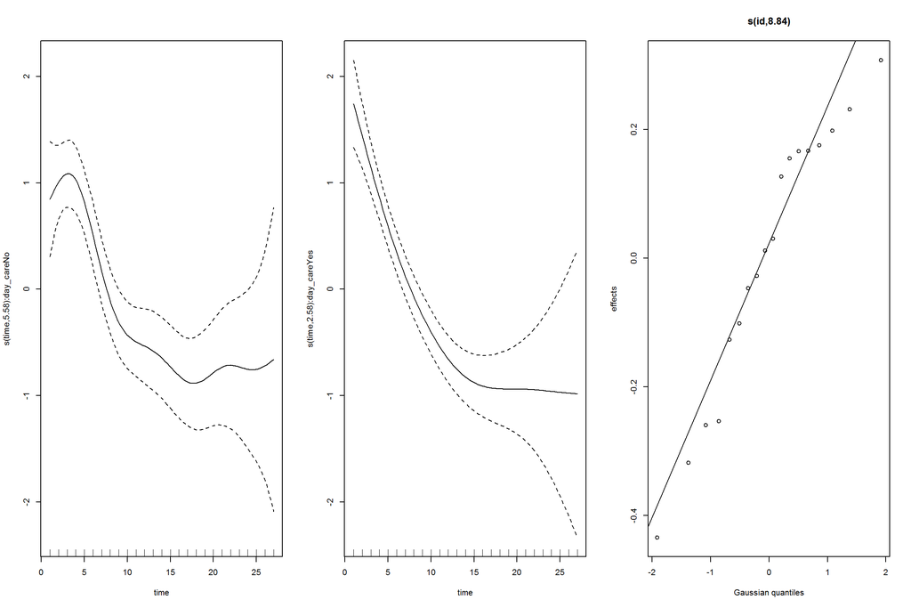

```r
par(mfrow = c(1, 3))
plot(dc_gam_2)
```

In the above plot, the far right describes the distribution of random intercepts

Plotting the summed effects without random effects:

```r
par(mfrow = c(1, 2))
# summed effects without random effects
# intercept + s(time):day_careYes
plot_smooth(dc_gam_2, view = "time", cond = list(day_care = "No"),
            rm.ranef = TRUE, main = "Intercept + s(time):day_careNo",
            rug = FALSE,
            ylab = "Log(q/mL)")
```

```
## Summary:
##  * day_care : factor; set to the value(s): No.
##  * time : numeric predictor; with 30 values ranging from 1.000000 to 27.000000.
##  * id : factor; set to the value(s): 216. (Might be canceled as random effect, check below.)
##  * NOTE : The following random effects columns are canceled: s(id)
##
```

```
## Summary:
##  * day_care : factor; set to the value(s): Yes.
##  * time : numeric predictor; with 30 values ranging from 1.000000 to 27.000000.
##  * id : factor; set to the value(s): 216. (Might be canceled as random effect, check below.)
##  * NOTE : The following random effects columns are canceled: s(id)
##
```

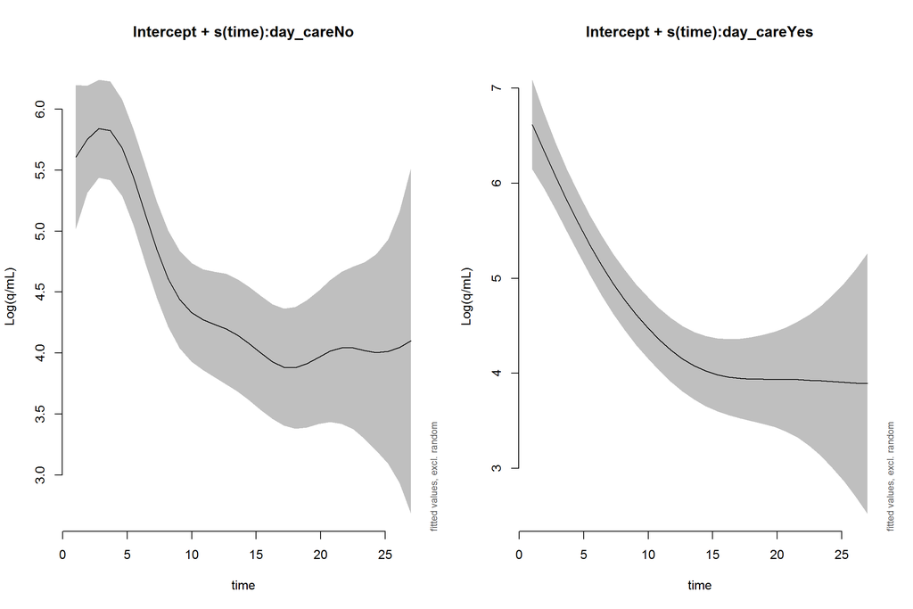

```r
plot_smooth(dc_gam_2, view = "time", cond = list(day_care = "Yes"),
            rm.ranef = TRUE, main = "Intercept + s(time):day_careYes",
            rug = FALSE,
            ylab = "Log(q/mL)")
```

Subject specific plots (random effects)

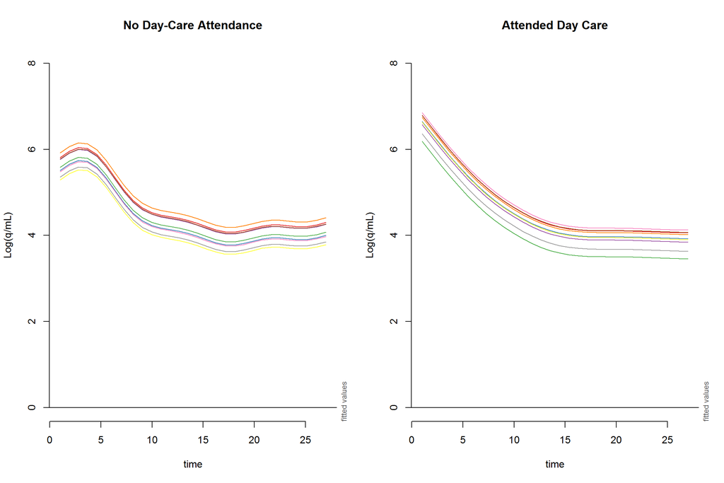

```r
no <- as.vector(with(df_red[df_red$day_care == "No",], unique(id)))
yes <- as.vector(with(df_red[df_red$day_care == "Yes", ], unique(id)))

plotSubjects <- function(df, day_care, fac, main) {
  df <- df; day_care <- day_care; fac <- fac
  myCols <- brewer.pal(9, "Set1")

  plot_smooth(df, view = "time",
              cond = list(day_care = day_care, id = fac[1]),
              main = main,
              col = myCols[1], se = FALSE,
              ylim = c(0, 8), rug = FALSE, ylab = "Log(q/mL)",
              print.summary = FALSE)

  for(i in 2:length(fac)) {
    plot_smooth(df,
                view = "time",
                cond = list(day_care = day_care, id = fac[i]),
                add = TRUE,
                col = myCols[i],
                se = FALSE,
                rug = FALSE,
                print.summary = FALSE)
  }
}

plotter <- function(df) {
  par(mfrow = c(1, 2))
  plotSubjects(df = df, day_care = "No", fac = no,
              main = "No Day-Care Attendance")
  plotSubjects(df = df, day_care = "Yes", fac = yes,
               main = "Attended Day Care")
}

plotter(df = dc_gam_2)
```

In the above model we only had about 42.3% of the deviance explained. We may be able to increase this by assuming a random slope component for each individual. Later I will incorporate more predictors/features which may similarly enhance our model fit.

```r
dc_gam_3 <- gam(log_q_per_ml ~ day_care + s(time, by = day_care) +
                  s(id, time, bs = "re"),
                data = df_red)
summary(dc_gam_3)
```

```
##
## Family: gaussian
## Link function: identity
##
## Formula:
## log_q_per_ml ~ day_care + s(time, by = day_care) + s(id, time,
##     bs = "re")
##
## Parametric coefficients:
##             Estimate Std. Error t value Pr(>|t|)
## (Intercept)   4.7292     0.1325  35.687   <2e-16 ***
## day_careYes   0.1084     0.1880   0.577    0.565
## ---
## Signif. codes:  0 '***' 0.001 '**' 0.01 '*' 0.05 '.' 0.1 ' ' 1
##
## Approximate significance of smooth terms:
##                       edf Ref.df      F  p-value
## s(time):day_careNo  5.503  6.619  7.868 3.17e-08 ***
## s(time):day_careYes 2.370  2.962 24.974 3.99e-14 ***
## s(id,time)          7.968 16.000  0.911   0.0331 *
## ---
## Signif. codes:  0 '***' 0.001 '**' 0.01 '*' 0.05 '.' 0.1 ' ' 1
##
## R-sq.(adj) =  0.372   Deviance explained = 40.9%
## GCV = 1.1513  Scale est. = 1.079     n = 284
```

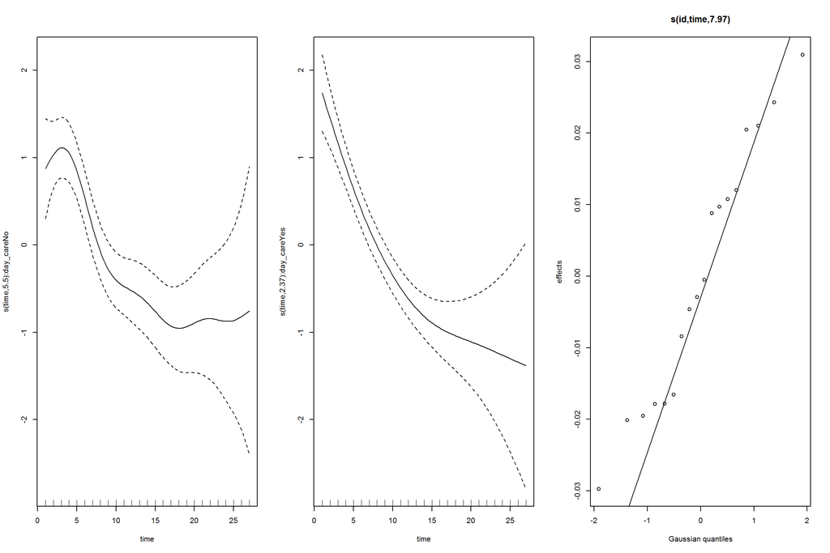

```r
par(mfrow = c(1, 3))
plot(dc_gam_3)
```

Ah, now the adj-$R^2$ and deviance explained has gone down.

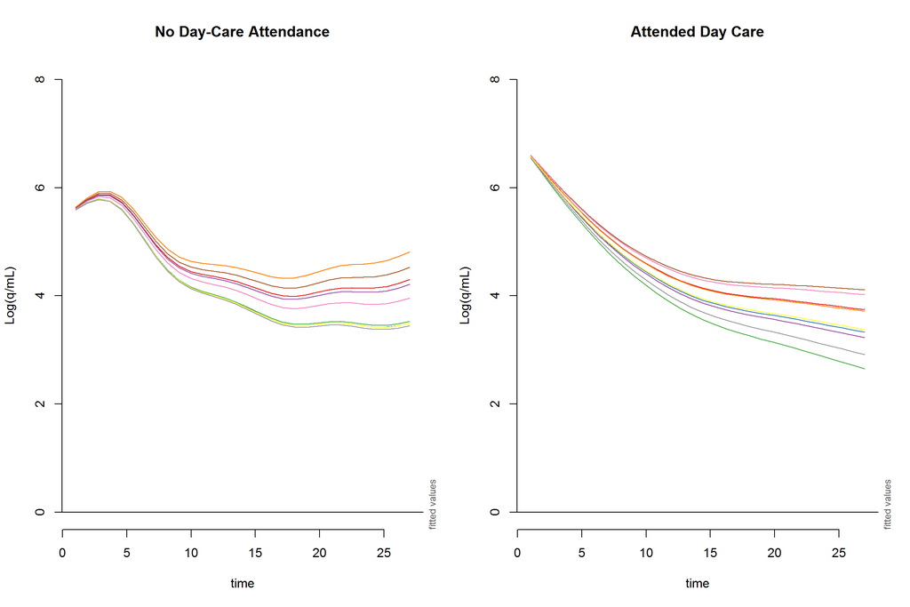

```r
plotter(df = dc_gam_3)
```

Random intercepts seem to make the most sense. Now to assess the fit once incorporating random intercepts and random slopes.

```r
dc_gam_4 <- gam(log_q_per_ml ~ day_care + s(time, by = day_care) +
                  s(id, bs = "re") + s(id, time, bs = "re"),
                data = df_red)
summary(dc_gam_4)
```

```
##
## Family: gaussian
## Link function: identity
##
## Formula:
## log_q_per_ml ~ day_care + s(time, by = day_care) + s(id, bs = "re") +
##     s(id, time, bs = "re")
##
## Parametric coefficients:
##             Estimate Std. Error t value Pr(>|t|)
## (Intercept)   4.7605     0.1340  35.524   <2e-16 ***
## day_careYes   0.1140     0.1898   0.601    0.549
## ---
## Signif. codes:  0 '***' 0.001 '**' 0.01 '*' 0.05 '.' 0.1 ' ' 1
##
## Approximate significance of smooth terms:
##                           edf Ref.df      F  p-value
## s(time):day_careNo  5.577e+00  6.692 10.243 5.92e-11 ***
## s(time):day_careYes 2.580e+00  3.219 29.826  < 2e-16 ***
## s(id)               8.837e+00 16.000  1.151   0.0095 **
## s(id,time)          5.730e-09 18.000  0.000   0.5018
## ---
## Signif. codes:  0 '***' 0.001 '**' 0.01 '*' 0.05 '.' 0.1 ' ' 1
##
## R-sq.(adj) =  0.384   Deviance explained = 42.3%
## GCV = 1.1338  Scale est. = 1.058     n = 284
```

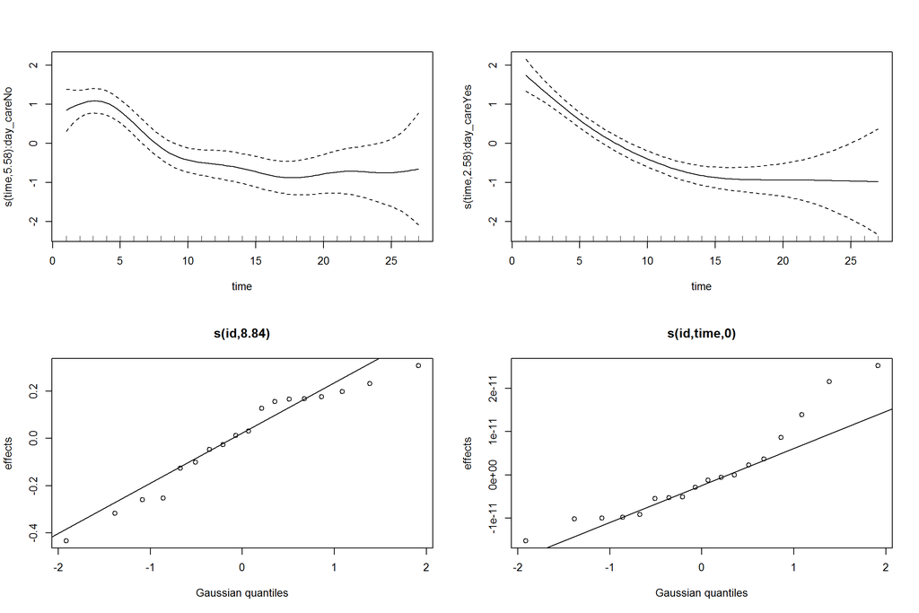

```r
par(mfrow = c(2, 2))
plot(dc_gam_4)
```

The deviance went back up but did not increase beyond $42.3%$ explained.

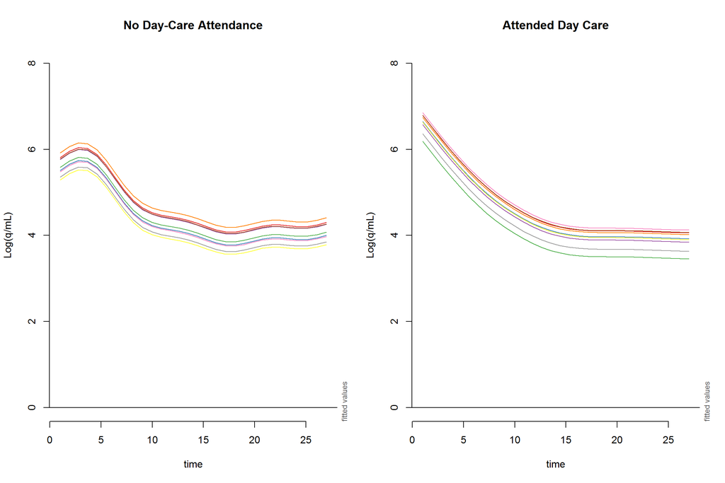

```r
plotter(df = dc_gam_4)
```

The random slope effect is not highly significant.

One more thing to try is random smooths. Upon examining the original data it is tempting to assume a mixture of viral trajectories. The following model can estimate these smooths.

```r
dc_gam_5 <- gam(log_q_per_ml ~ day_care + s(time, by = day_care) +
                  s(time, id, bs = "fs", m = 1),
                data = df_red)
summary(dc_gam_5)
```

```
##
## Family: gaussian
## Link function: identity
##
## Formula:
## log_q_per_ml ~ day_care + s(time, by = day_care) + s(time, id,
##     bs = "fs", m = 1)
##
## Parametric coefficients:
##             Estimate Std. Error t value Pr(>|t|)
## (Intercept)   4.7489     0.1419  33.478   <2e-16 ***
## day_careYes   0.1333     0.2011   0.663    0.508
## ---
## Signif. codes:  0 '***' 0.001 '**' 0.01 '*' 0.05 '.' 0.1 ' ' 1
##
## Approximate significance of smooth terms:
##                        edf  Ref.df      F  p-value
## s(time):day_careNo   5.512   6.600  8.316 1.09e-08 ***
## s(time):day_careYes  2.546   3.148 24.368 1.64e-14 ***
## s(time,id)          15.521 159.000  0.173  0.00767 **
## ---
## Signif. codes:  0 '***' 0.001 '**' 0.01 '*' 0.05 '.' 0.1 ' ' 1
##
## R-sq.(adj) =    0.4   Deviance explained = 45.2%
## GCV = 1.1316  Scale est. = 1.0297    n = 284
```

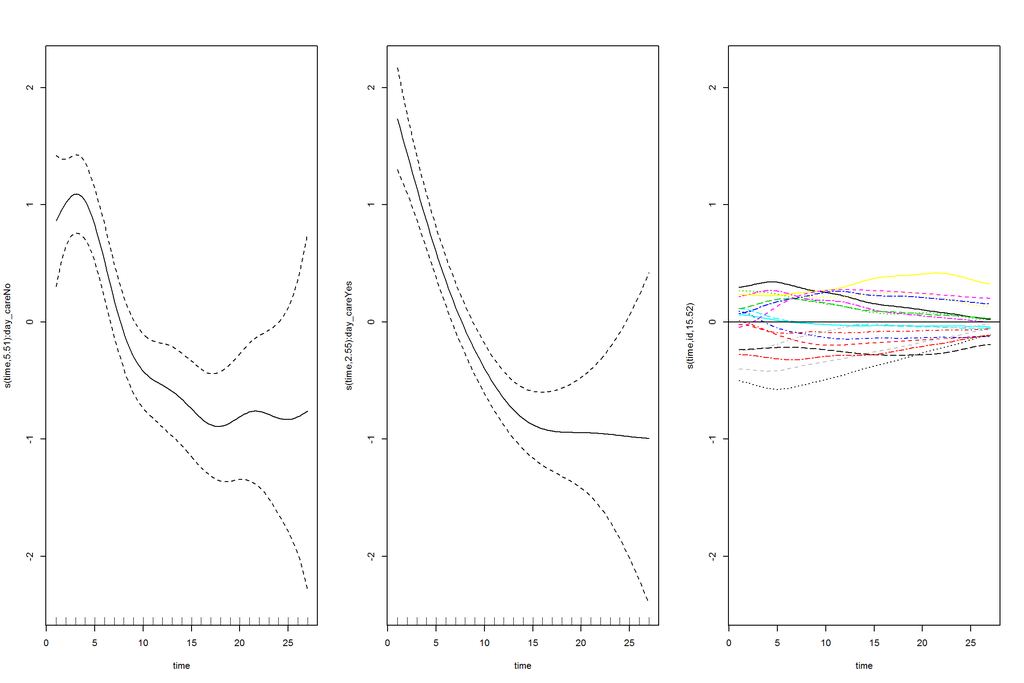

```r
par(mfrow = c(1, 3))
plot(dc_gam_5, select = 1)
plot(dc_gam_5, select = 2)
plot(dc_gam_5, select = 3)
abline(h = 0)
```

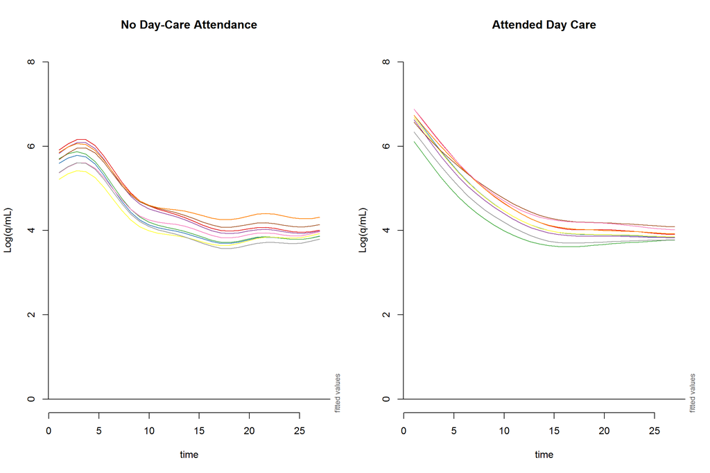

```r
plotter(df = dc_gam_5)
```

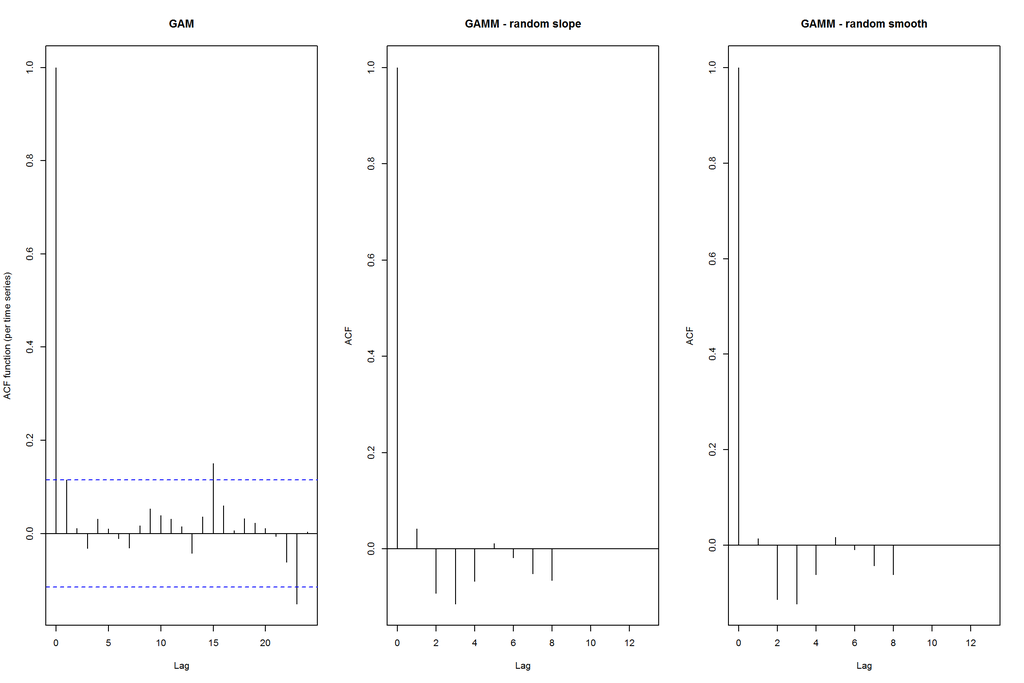

```r
par(mfrow = c(1, 3))
acf_resid(dc_gam_1, main = "GAM")
acf_resid(dc_gam_3, split_pred = "id", main = "GAMM - random slope")
acf_resid(dc_gam_5, split_pred = "id", main = "GAMM - random smooth")
```

Full Model

```r
full_gam_1 <- gam(log_q_per_ml ~ day_care + female + siblings + bf_duration +
                    s(time, by = day_care) +
                    s(time, by = female) +
                    s(time, by = siblings) +
                    s(time, id, bs = "fs", m = 1),
                  data = df_red)

summary(full_gam_1)
```

```
##
## Family: gaussian
## Link function: identity
##
## Formula:
## log_q_per_ml ~ day_care + female + siblings + bf_duration + s(time,
##     by = day_care) + s(time, by = female) + s(time, by = siblings) +
##     s(time, id, bs = "fs", m = 1)
##
## Parametric coefficients:
##               Estimate Std. Error t value Pr(>|t|)
## (Intercept)   4.885802   0.274298  17.812   <2e-16 ***
## day_careYes   0.070346   0.229846   0.306    0.760
## femaleFemale  0.165881   0.220481   0.752    0.453
## siblingsYes   0.083372   0.221691   0.376    0.707
## bf_duration  -0.005802   0.004386  -1.323    0.187
## ---
## Signif. codes:  0 '***' 0.001 '**' 0.01 '*' 0.05 '.' 0.1 ' ' 1
##
## Approximate significance of smooth terms:
##                          edf   Ref.df     F p-value
## s(time):day_careNo    0.6667   0.6667 2.743  0.1775
## s(time):day_careYes   3.2946   4.1020 2.506  0.0498 *
## s(time):femaleMale    0.6667   0.6667 2.205  0.2264
## s(time):femaleFemale  1.7210   2.1809 2.911  0.0644 .
## s(time):siblingsNo    0.6667   0.6667 3.119  0.1505
## s(time):siblingsYes   8.2437   8.5151 2.384  0.0089 **
## s(time,id)           16.2968 157.0000 0.167  0.0152 *
## ---
## Signif. codes:  0 '***' 0.001 '**' 0.01 '*' 0.05 '.' 0.1 ' ' 1
##
## Rank: 219/221
## R-sq.(adj) =  0.426   Deviance explained = 49.8%
## GCV =  1.132  Scale est. = 0.98629   n = 284
```

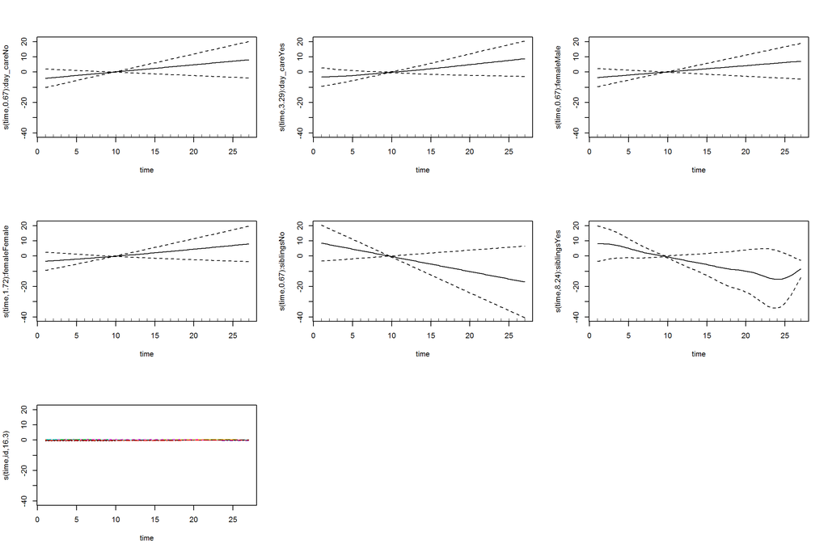

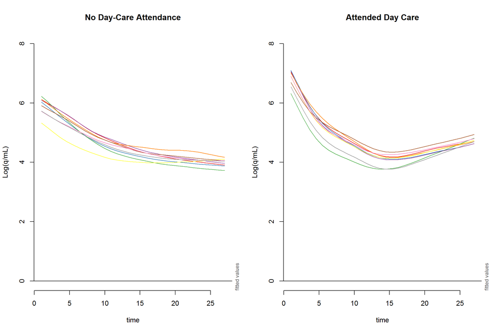

```r
par(mfrow = c(3, 3))
plot(full_gam_1);

plotter(full_gam_1)
```

The residuals don’t look great, I don’t believe the problem comes down to autocorrelation in residuals but I will adjust for this by including an AR1 autocorrelation into the model. We need two things, first the start of each individual event and then the ‘rho’ parameter which will be the lags of our predicted model time.

```r
# I like this function, I wonder which is faster...
# library(microbenchmark)
# test <- df_red %>% arrange(id, time)
# microbenchmark(
#   itsadug::start_event(test, column = "time", event = "id"),
#
#   test %>%
#     group_by(id) %>%
#     mutate(start.event = row_number() == 1),
#
#   plyr::ddply(test, "id",
#               transform,
#               start.event = seq(length(id)) == 1)
# )
# The itsadug::start_event function is slower and ddply is much slower,
# I will stick with dplyr

df_first <- df_red %>%
  group_by(id) %>%
  mutate(start.event = row_number() == 1)

Rho <- acf(resid(full_gam_1), plot = FALSE)$acf[2]

full_gam_ar1 <- update(full_gam_1,
                       AR.start = df_first$start.event,
                       rho = Rho)
summary(full_gam_ar1)
```

```
##
## Family: gaussian
## Link function: identity
##
## Formula:
## log_q_per_ml ~ day_care + female + siblings + bf_duration + s(time,
##     by = day_care) + s(time, by = female) + s(time, by = siblings) +
##     s(time, id, bs = "fs", m = 1)
##
## Parametric coefficients:
##               Estimate Std. Error t value Pr(>|t|)
## (Intercept)   4.885802   0.274298  17.812   <2e-16 ***
## day_careYes   0.070346   0.229846   0.306    0.760
## femaleFemale  0.165881   0.220481   0.752    0.453
## siblingsYes   0.083372   0.221691   0.376    0.707
## bf_duration  -0.005802   0.004386  -1.323    0.187
## ---
## Signif. codes:  0 '***' 0.001 '**' 0.01 '*' 0.05 '.' 0.1 ' ' 1
##
## Approximate significance of smooth terms:
##                          edf   Ref.df     F p-value
## s(time):day_careNo    0.6667   0.6667 2.743  0.1775
## s(time):day_careYes   3.2946   4.1020 2.506  0.0498 *
## s(time):femaleMale    0.6667   0.6667 2.205  0.2264
## s(time):femaleFemale  1.7210   2.1809 2.911  0.0644 .
## s(time):siblingsNo    0.6667   0.6667 3.119  0.1505
## s(time):siblingsYes   8.2437   8.5151 2.384  0.0089 **
## s(time,id)           16.2968 157.0000 0.167  0.0152 *
## ---
## Signif. codes:  0 '***' 0.001 '**' 0.01 '*' 0.05 '.' 0.1 ' ' 1
##
## Rank: 219/221
## R-sq.(adj) =  0.426   Deviance explained = 49.8%
## GCV =  1.132  Scale est. = 0.98629   n = 284
```

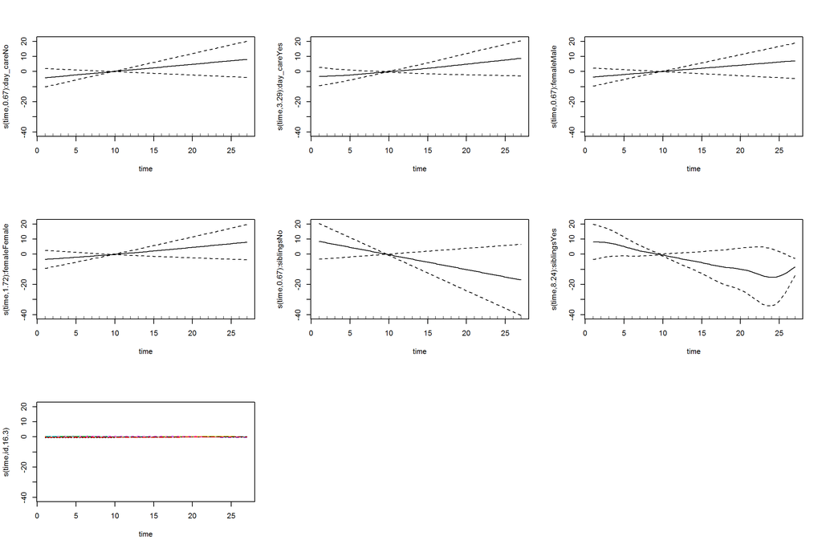

```r
par(mfrow = c(3, 3))
plot(full_gam_1)
```

This only helped to show that the AR1 correlation structure is non-significant and we don’t have autocorrelated residual issues.

Difference smooths on day_care to test differences in trends. First need to change to treatment encoding. Without this sort of encoding we will not see differences in trends between groups, as evidenced above in the plot(full_gam_1)

```r
df_red$order_dc <- as.ordered(df_red$day_care)
contrasts(df_red$order_dc) <- 'contr.treatment'
contrasts(df_red$order_dc)
```

```
##     Yes
## No    0
## Yes   1
```

```r
full_gam_2 <- gam(log_q_per_ml ~ order_dc + female + siblings + bf_duration +
                    s(time, by = order_dc) +
                    s(time, by = female) +
                    s(time, by = siblings) +
                    s(id, bs = "re") +
                    s(time, id, bs = "fs", m = 1),
                  data = df_red)

summary(full_gam_2)
```

```
##
## Family: gaussian
## Link function: identity
##
## Formula:
## log_q_per_ml ~ order_dc + female + siblings + bf_duration + s(time,
##     by = order_dc) + s(time, by = female) + s(time, by = siblings) +
##     s(id, bs = "re") + s(time, id, bs = "fs", m = 1)
##
## Parametric coefficients:
##               Estimate Std. Error t value Pr(>|t|)
## (Intercept)   4.886814   0.265609  18.399   <2e-16 ***
## order_dcYes   0.079858   0.222417   0.359    0.720
## femaleFemale  0.146721   0.213975   0.686    0.494
## siblingsYes   0.016960   0.208109   0.081    0.935
## bf_duration  -0.005560   0.004247  -1.309    0.192
## ---
## Signif. codes:  0 '***' 0.001 '**' 0.01 '*' 0.05 '.' 0.1 ' ' 1
##
## Approximate significance of smooth terms:
##                         edf  Ref.df     F p-value
## s(time):order_dcYes   3.621   4.436 2.492 0.05112 .
## s(time):femaleMale    0.750   0.750 0.012 0.92523
## s(time):femaleFemale  1.880   2.380 2.221 0.14063
## s(time):siblingsNo    0.750   0.750 0.958 0.39737
## s(time):siblingsYes   6.048   6.946 1.967 0.06321 .
## s(id)                 2.677  13.000 0.221 0.00872 **
## s(time,id)           10.271 154.000 0.104 0.21857
## ---
## Signif. codes:  0 '***' 0.001 '**' 0.01 '*' 0.05 '.' 0.1 ' ' 1
##
## Rank: 229/230
## R-sq.(adj) =  0.414   Deviance explained = 47.6%
## GCV = 1.1304  Scale est. = 1.007     n = 284
```

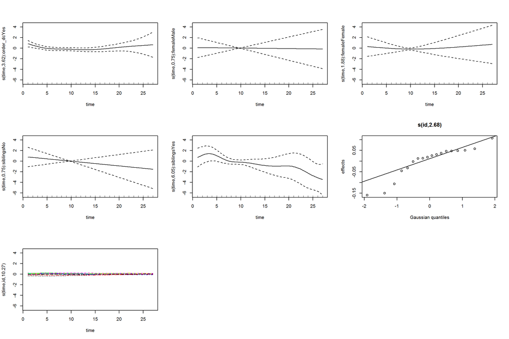

```r
par(mfrow = c(3, 3))
plot(full_gam_2)
```